# NFL Weather Data Documentation

# Weather Data Released

Weather can play an important part of an NFL game, but data with the conditions for various games can be hard to find. This document will describe the process for acquiring weather data via the [meteostat API](https://api.meteostat.net/) and matching to NFL game id’s. This document also links to a [historical archive of NFL game weather data](https://github.com/ThompsonJamesBliss/WeatherData) beginning with the year 2000.

## Included Files

The files can be found [here](https://github.com/ThompsonJamesBliss/WeatherData). The files are as follows:

`stadium_coordinates.csv`

- `StadiumName`: name of stadium.
- `RoofType`: whether the stadium is indoor, outdoor or has a retractable roof.
- `Longitude`: longitude of the stadium.
- `Latitude`: latitude of the stadium.
- `StadiumAzimuthAngle`: azimuth angle of the field (0 is North, 90 is East, 180 is South, 270 is West).

`games.csv`

- `game_id`: id corresponding to game.
- `Season`: season game takes place.
- `StadiumName`: name of stadium.
- `TimeStartGame`: date and time game started in local timezone.
- `TimeEndGame`: date and time game ended in local timezone.
- `TZOffset`: hours offset from local timezone of game to UTC timezone.

`games_weather.csv`

- `game_id`: id corresponding to game.
- `Source`: source of weather data (meteostat or Wunderground).
- `DistanceToStation`: distance from stadium to station in miles.
- `TimeMeasure`: date and time weather was measured in local timezone.
- `Temperature`: temperature in Fahrenheight.
- `DewPoint`: dew point in Fahrenheight.
- `Humidity`: humidity in percentage.
- `Precipitation`: precipitation in inches.
- `WindSpeed`: speed of wind in miles per hour.
- `WindDirection`: azimuth angle of the direction of wind (0 is North, 90 is East, 180 is South, 270 is West).
- `Pressure`: pressure in inches of mercury.

## Acquiring the Weather Data

To acquire the weather data, the [meteostat API](https://api.meteostat.net/) was used to obtain JSON files of weather station locations and the weather readings for a particular date and time. In order to use, one must register for the completely free API, but be aware that it has limits on calls per hour.

```r
library(tidyverse)
```

The first step is to find the weather stations that are close to each NFL Stadium. To do this, the longitude for each stadium, latitude for each stadium and the dates of games are needed. They can be found in `stadium_coordinates.csv` and `games.csv`.

```r
#loading coordinate data
df_coordinates <- readr::read_csv('stadium_coordinates.csv')
df_games <- readr::read_csv('games.csv')
```

In order to capture each season, it is ideal to perform one API query per season per location. To do so, it is necessary to acquire a max and min date of the season and merge the dates to coordinates for each location.

```r
#converting dates to dates and not characters
df_games <- df_games  %>%

  mutate(
    TimeStartGame = lubridate::parse_date_time(TimeStartGame, orders = '%m/%d/%Y %H:%M'),
    TimeEndGame = lubridate::parse_date_time(TimeEndGame, orders = '%m/%d/%Y %H:%M')
  )


#will be used for weather fetching
df_weather_fetch <- df_games  %>%

  #grouping by season
  group_by(Season) %>%

  #determining first and last date of each season - adding buffer to make sure data is captured
  #using substring, since want date only is needed and it is fine to leave as character as itll be part of API call
  mutate(first_date = substr(min(TimeStartGame) - lubridate::days(1), 1, 10),
         last_date = substr(max(TimeEndGame) + lubridate::days(1), 1, 10)) %>%

  #ungrouping
  ungroup() %>%

  #joining the coordinates
  inner_join(df_coordinates, by = c("StadiumName" = "StadiumName")) %>%

  #selecting relevelnt columns
  select(Season, StadiumName, Longitude, Latitude, first_date, last_date)
```

To begin using the API to fetch the weather data, iterate through each row of `df_weather_fetch` and query weather data from every station within a 50 kilometer radius of the stadium and append to a dataframe or csv. Please note that once an API key runs out of API calls there will be an HTTP Error.

```r
#will store results
df_weather_raw <- data.frame()

API_KEY = '' #INSERT YOUR API KEY HERE

#iterating through each season and location
for(i in seq(1, nrow(df_weather_fetch))){


  #selecting row
  row <- df_weather_fetch[i,]

  #Query to find every station within 50 km of given longitude and latitude
  #make sure to set API_KEY with your registered API_KEY
  #setting limit to 99 to maximize stations reached
  query_station = paste0('https://api.meteostat.net/v1/stations/nearby?lat=',
                         row$Latitude,'&lon=',row$Longitude,'&limit=99&key=',API_KEY)

  #running station query
  query_result_station = jsonlite::fromJSON(query_station)$data %>% as.data.frame()


  #iterating through each station
  for(j in seq(1, nrow(query_result_station))){

    #query to get weather for given station and date
    query_weather = paste0('https://api.meteostat.net/v1/history/hourly?station=',
                           query_result_station$id[j],'&start=',row$first_date,
                           '&end=',row$last_date,'&key=',API_KEY)

    #running query
    query_result_weather = jsonlite::fromJSON(query_weather)$data

    #many times result will be empty list
    if(length(query_result_weather) > 0){



      df_weather_raw <- bind_rows(df_weather_raw,
                                  cbind(row  %>%
                                          mutate(distance = query_result_station$distance[j]),
                                        query_result_weather %>% as.data.frame()))



    }




  }



}
```

## Cleaning the Weather Data

First, columns that are essentially completely NA as and columns that are no longer needed (including `Longitude`, `Latitude`, `first_date` and `last_date`) are dropped:

```r
df_weather_raw <- df_weather_raw %>%
  select(-c('precipitation_3', 'precipitation_6', 'snowdepth',
            'first_date', 'last_date', 'peakgust', 'Longitude', 'Latitude', 'condition'))
```

It is ideal to use the closest possible station for each stadium. However, before proceeding, NA values must be dealt with. An easy solution that accounts for most of the NA values is to fill from the next closest station:

```r
#cleaning the raw weather data
df_weather_raw <- df_weather_raw %>%

  #converting time to date time
  mutate(time = lubridate::parse_date_time(time, orders = c("%Y-%m-%d %H:%M:%S", "%m/%d/%Y %H:%M"))) %>%

  #grouping by season, site and time
  group_by(Season, StadiumName, time) %>%

  #dealing with NA
  arrange(distance) %>%

  #filling NA of closer distanced weather stations with further weather stations
  fill(c('temperature', 'dewpoint', 'humidity', 'precipitation',
         'windspeed', 'winddirection', 'pressure'), .direction = 'up') %>%

  #ungrouping
  ungroup()
```

Now, all data that is not from the station with the minimum distance to the stadium is filtered out:

```r
#cleaning the raw weather data
df_weather_raw <- df_weather_raw %>%

  #grouping by season, site and time
  group_by(Season, StadiumName, time) %>%

  #filtering for only closest distance to stadium
  filter(distance == min(distance)) %>%

  #ungrouping
  ungroup()
```

Next, the remaining NA is dealt with by using a linear approximation:

```r
df_weather_raw <- df_weather_raw %>%

  #filling remaining NA with moving average
  group_by(Season, StadiumName) %>%

  arrange(time) %>%

  #filling NA with linear approximation - precipitation/wind direction cannot be well predicted this way
  mutate_at(vars('temperature', 'dewpoint',
                 'humidity', 'windspeed', 'pressure'), ~zoo::na.approx(., maxgap = 3, na.rm = F)) %>%

  #ungrouping
  ungroup()
```

```r
#conversion between celcius and fahrenheit
celcius2Fahrenheit_slope <- 9/5
celcius2Fahrenheit_intercept <- 32
mm2Inches <- 0.039370
km2Miles <- 0.621371
hPa2Inches <- 0.02952998

#raw weather data
df_weather_raw <- df_weather_raw %>%

   mutate(
    TimeMeasure = time,

    #making direction go from 0 to 360, and setting as NA if no wind speed
    WindDirection = ifelse(windspeed == 0, NA, winddirection)  %% 360,

    #fixing issues where humidity can be greater than 100%
    Humidity = ifelse(humidity > 100, 100, humidity),

    #converting Celcius to Fahrenheit
    Temperature = round(temperature * celcius2Fahrenheit_slope + celcius2Fahrenheit_intercept, 2),
    DewPoint = round(dewpoint * celcius2Fahrenheit_slope + celcius2Fahrenheit_intercept, 2),

    #converting milimeters to inches
    Precipitation = round(precipitation * mm2Inches, 3),

    #converting km / hour to miles / hour
    WindSpeed = round(windspeed * km2Miles, 2),

    #converting km to miles
    DistanceToStation = round(as.numeric(distance) * km2Miles, 2),

    #converting hPa to inches of mercury
    Pressure = round(pressure *  hPa2Inches, 4),

    #determining condtion from precipitation and temperature
    EstimatedCondition = ifelse(Precipitation == 0, "Clear", "Rain"),
    EstimatedCondition = ifelse(Precipitation > 0,
                                ifelse(Temperature <= 34, "Snow", "Rain"),
                                EstimatedCondition),
    EstimatedCondition = ifelse(EstimatedCondition %in% c("Snow", "Rain"),
                                paste0(case_when(Precipitation < 0.098 ~ "Light ",
                                                 Precipitation > 0.3 ~ "Heavy ",
                                                 T ~ "Moderate "), EstimatedCondition),
                                EstimatedCondition))  %>%

  #selecting relevant columns
  select(StadiumName, Season, DistanceToStation, TimeMeasure, Temperature,
         DewPoint, Humidity, Precipitation, WindSpeed, WindDirection, Pressure)
```

## Merging Weather Data

The weather data is joined to the games data by season and location and then measurement times that are outside of the game times are filtered out. The `TimeStartFilter` and `TimeEndFilter` variables are created for this filtering. The variables are converted to UTC time and have a buffer to ensure all wanted data is kept.

```r
df_games <- df_games %>%
  mutate(TimeStartFilter = TimeStartGame - lubridate::hours(TZOffset) - lubridate::hours(1),
         TimeEndFilter = TimeEndGame  - lubridate::hours(TZOffset) + lubridate::hours(2))
```

Finally, one must merge and filter out the unwanted measurements. For memory issues, it is best to do this process in chunks:

```r
#joining each season and rbinding for memory issues
df_weather_games <- data.frame()

#joining weather data in pieces to prevent memorhy error
for(s in seq(2000, 2020)){


  #rbinding to what is currently there
  df_weather_games <- rbind(df_weather_games,


    #taking games only for this season
    df_games %>%

    filter(Season == s) %>%

      #taking weather only for this season
    left_join(df_weather_raw %>% filter(Season == s),



                    by = c("Season" = "Season",
                           "StadiumName" = "StadiumName")) %>%


      #removing unnecessary rows
      filter( ((TimeMeasure >= TimeStartFilter) & (TimeMeasure <= TimeEndFilter)) ) %>%

      #readjusting to local time
      mutate(TimeMeasure = TimeMeasure + lubridate::hours(TZOffset))
      )


}

#remove unwanted columns
df_weather_games <- df_weather_games %>% select(-c('TimeStartFilter', 'TimeEndFilter',
                                                   'TZOffset', 'Season', 'StadiumName'))
```

The data is cleaned and ready to analyze and visualize. All games with completely missing data were supplemented by copying and pasting from Wunderground.

## Plotting Results

Now that the data is clean, it can be visualized. The following code creates a simple plot showing the general wind speed trends at every outdoor stadium.

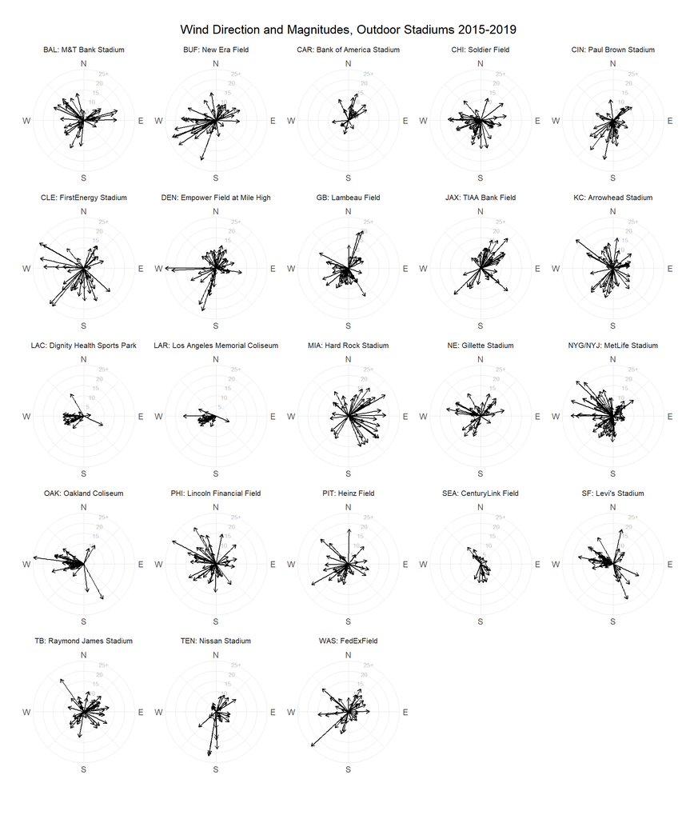

```r
#used for plot values
plot_vals <- df_weather_games %>%

  group_by(game_id) %>%

  #selecting 1st read of wind
  slice(1) %>%

  #joing games
  inner_join(df_games) %>%

  #joing coordinates
  inner_join(df_coordinates) %>%

  #applying filters
  filter(RoofType == "Outdoor", Season >= 2015) %>%

  #renaming stadium
  mutate(StadiumNameAdj = paste0(HomeTeam, ': ', StadiumName),

         #limiting max value of wind speed
         WindSpeed = ifelse(WindSpeed >= 25, 25, WindSpeed)) %>%

  #selecting values of interest
  select(StadiumNameAdj, WindSpeed, WindDirection) %>%

  #grouping by stadium
  group_by(StadiumNameAdj) %>%

  #filtering for only 20 or more observations
  filter(n() > 20) %>%

  #ungrouping
  ungroup()



set.seed(0)

## Add random noise (WindDirection comes in multiples of 10)
plot_vals$WindDirection <- plot_vals$WindDirection + rnorm(nrow(plot_vals), 0, 3)


#will be used for axis text
key <- expand.grid(WindDirection = 45/2, WindSpeed = c(5, 10, 15, 20, 25),
                   StadiumNameAdj = unique(plot_vals$StadiumNameAdj)) %>%
  mutate(WindLabel = ifelse(WindSpeed == 25, " 25+", WindSpeed))


plot_vals %>%

  ggplot(aes(x = WindDirection, y = WindSpeed)) +

  #axis lines
  geom_hline(yintercept = seq(0, 25, by = 5), colour = "grey90", size = 0.2) +
  geom_vline(xintercept = seq(0, 360-1, by = 45), colour = "grey90", size = 0.2) +

  #axis text
  geom_text(data = key, aes(label = WindLabel), colour = "grey", size = 2.2) +

  #vectors
  geom_segment(aes(y = 0, xend = WindDirection, yend = WindSpeed),
               arrow = arrow(length = unit(0.03, "npc"))) +
  coord_polar(start = 0) + xlab('') +

  #removing y label
  ylab('') +

  #scale
  scale_x_continuous(breaks = c(0, 90, 180, 270), labels = c("N", "E", "S", "W"), lim = c(0,360)) +
  scale_y_continuous(lim = c(0, 25)) +

  #black white theme
  theme_bw() +

  #title
  ggtitle("Wind Direction and Magnitudes, Outdoor Stadiums 2015-2019") +

  #faceting by stadium
  facet_wrap(~StadiumNameAdj, nrow = 5) +

  #theme
  theme(
    plot.title = element_text(hjust = 0.5),
    plot.subtitle = element_text(hjust = 0.5),
    axis.text.y = element_blank(),
    axis.ticks.y = element_blank(),
    strip.background = element_blank(),
    strip.text = element_text(size = 8),
    panel.border  = element_blank(),
    panel.grid = element_blank()
  )
```